# Zillow EDA

Quang

10 août 2017

This is q quick EDA for the Zillow data set, the goal is to understand the data, not to visualize it, so the quality of the graphics will not be magnificent.

## Data loading

```r
options( warn = -1 )
library(data.table)
library(dplyr)
library(lubridate)
library(ggplot2)

#Read the data
label = fread("C:/Quang/Kaggle/Data/train_2016_v2.csv/train_2016_v2.csv")
train = fread("C:/Quang/Kaggle/Data/properties_2016.csv/properties_2016.csv")
test = fread("C:/Quang/Kaggle/Data/sample_submission.csv/sample_submission.csv")

#Formatting the data
label$transactiondate = as.Date(label$transactiondate, "%Y-%m-%d")
```

First look at the response variable:

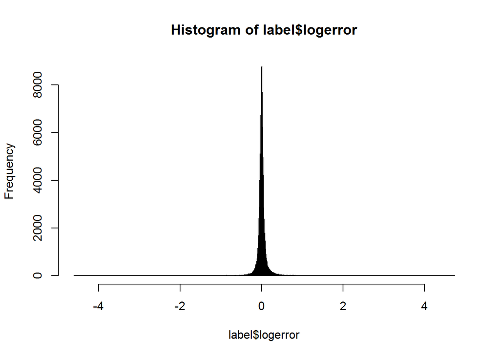

```r
hist(label$logerror, breaks = 1000)
```

The min and the max are far away -> possible outlier

**Takeaway 1**: Capping / Collaring could improve the model

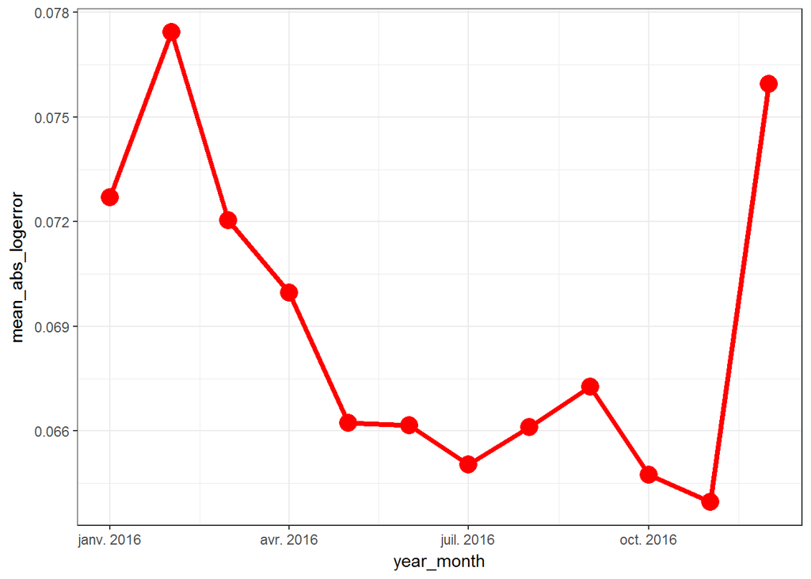

```r
#Log error over time
label <- label %>% mutate(abs_logerror = abs(logerror))
label %>%
  mutate(year_month = make_date(year=year(transactiondate),month=month(transactiondate)) ) %>%
  group_by(year_month) %>% summarize(mean_abs_logerror = mean(abs_logerror)) %>%
  ggplot(aes(x=year_month,y=mean_abs_logerror)) +
  geom_line(size=1.5, color="red")+
  geom_point(size=5, color="red")+theme_bw()
```

- Quick conclusion:
  - The predictions of Zillow gets better over time
  - But why there is a peak after October 2016?
  - May be it is just a seasonality effect, not the prediction quality
- Thoughful conclusion:
  - The time interval is just one year, it could be just a seasonality effect, not an improvement of Zillow’s model
  - We don’t know that, hence *to be check* when the 2017 data is available

**Takeaway 2**: Change the weight of the observations at the same period of the testing set would be beneficial, not many people will remark that, so it could be the key point to progress on the leaderboad. So let’s hope that it’s a seasonality effect If it is a seasonality effect, we will give more weight to the observations at the same perid as the testing set